# Exercise: Big data, climate indices and spatial mapping

# 1 Introduction

We’re leaving Freiburg and our HOBO-timeseries going to big(ger) datasets and a larger spatial scale. Now we are using a selection of 30 DWD-stations in Baden-Württemberg with different hydrometeorological variables.

## 1.1 Assignment

Go to the GoogleSheet (Metafile) and indicate what station you work with and assign also for the groupwork in the Indices Sheet (groups of 2-3 people per index).

https://docs.google.com/spreadsheets/d/1lAU7Qgjcfhhc13QX3gf6sLY3Zr1P-rY_h8KD9wGRgBI/edit#gid=797479261

## 1.2 Data

Data is available in a `tibble`-data_frame on the Moodle site. Download it and unzip the file. Data is stored tabstop-separated, you can use `read_tsv()` from the tidyverse-packages. The tidyverse resources (e.g. packages dplyr, ggplot etc.) are highly recommended for this exercise.

## 1.3 The workflow for this exercise

- You (alone) are responsible for one station.
- Your group is responsible to deliver a R function for one index calculation.
- “First come first serve” to choose a station and a index.
- You can use later on the provided R functions from the other groups to calculate all your indices for your station. If you have to wait you can also calculate the indices for yourself.
- All R functions will be available on github.com (see Section 4)
- If you find errors in functions from other students, please discuss the issue and help to provide an update of the R function.

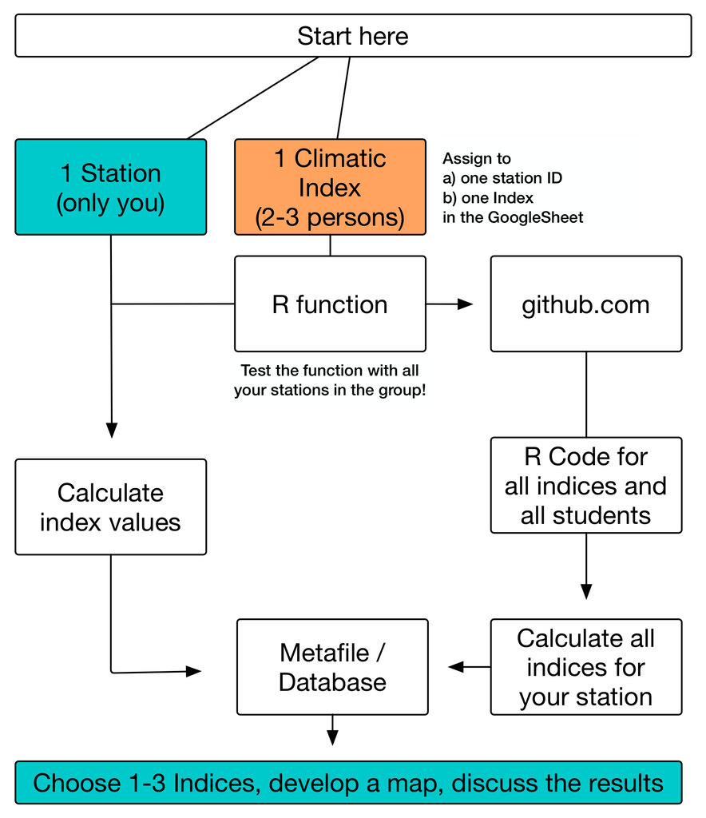

Figure: Flow chart Exercise “Climate Index BW”

# 2 Climate indices: BW stations (2nd week)

## 2.1 Aim(s)

The aim is to visualize how the climate has (not) changed at certain points in Baden-Württemberg. This exercise is a combination of temporal station data and spatial data that will be available through the index calculation. At the end maps of Baden-Württemberg can be created with let’s say 20-25 point informations and a spatial pattern hopefully will emerge from this pattern of points, at least for some of the indices.

## 2.2 Climate indices

To have the data basis for that we need all of you to calculate

1. the average of your index based on the annual values you have calculated, but also
2. a rate of change that is defined for each Index ABC as:

$$\Delta ABC = \frac{ABC_{1997-2016}} {ABC_{1977-1996}}$$
to quantify the change in Index value between the first 20 years and the last 20 years of the time series. Note that *1997-2016* is *1997-01-01* until *2016-12-31* and *1977-1996* is *1977-01-01* until *1996-12-31*.

- Then all indices should be calculated for each station. The index calculation is prepared in groups (2-3 persons). Each group generates a genric function in R to calcualte a specific index. Therefore the group should also fill the names of all persons in the group into the meta list.
- There are two indices that relate calculation to the climatic normal period (1961-1990). As you do not have the data for this period, please put your “climatic normal period” to 1977-1996 (just first 20 years).
- Please be aware of the listed units for each index! It is very important that each group consider the required units for index calculating!!!
- Your R function should calculate *at least* the *two* index values listed above.

## 2.3 List of avaiable indices

Index #143 and #144 might be good for a group with more advanced R skills, the other indices are more on the “beginner” or “intermediate” level, let’s have a look.

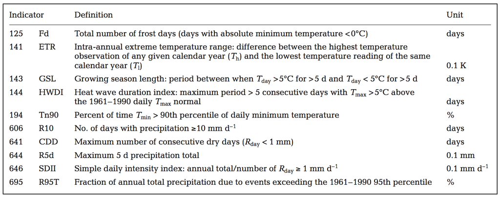

Figure: List of indices to access climate change

Read/check the corresponding paper (Frich et al. on Moodle) and discuss the specific functionality of your index o r the other indices. Which indices are based on precipiation? Which indcies are based on temperature? Does the index characterize a specific “part” (e.g. wetness, seasonality, extrem events etc…) of the climate in Baden-Württemberg? … …

## 2.4 Meta information for the 30 climate stations

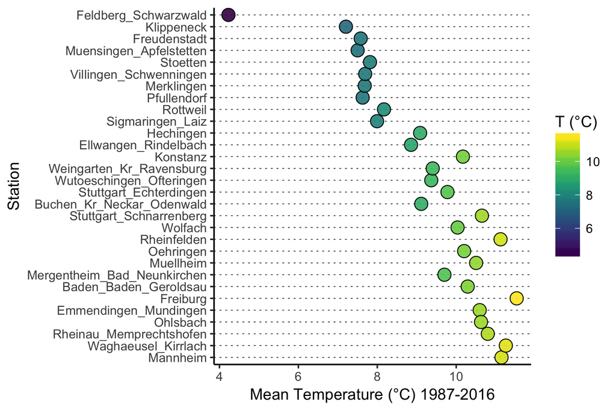

Figure: 30 Climate stations in BW, here overview of mean temperature.

You can load the *DWD Climate Stations BW Metafile* from Moodle to your R environment to inspect the meta data of the stations.

You can create a simple map (shape contour) of Baden-Württemberg as a `geom_polygon` with `ggplot`. Data for that is stored in `bw_shape.txt` (Downoad in Moodle). More sophisticated solutions are e.g. possible with QGIS or the R package `ggmap`.

```r
# not run, example code:
shape <- read_tsv("bw_shape.txt")
ggplot(data = shape , aes(x = coordsx , y = coordsy)) +
    geom_polygon(fill="white", colour="grey50", size=1)
```

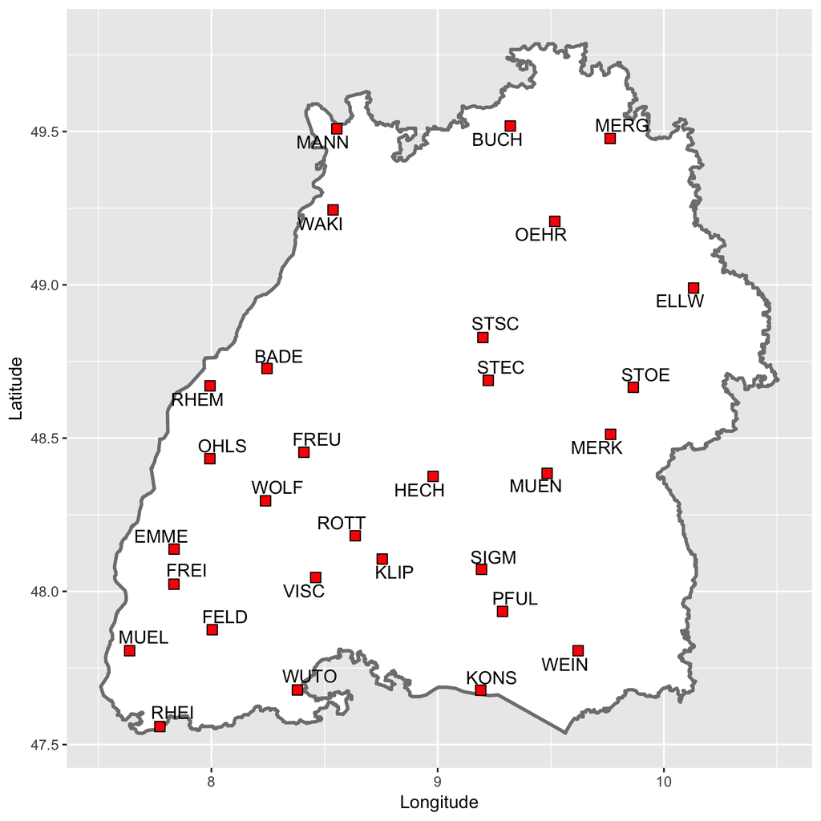

Figure: Map of 30 Climate stations in BW.

| id | station | short_stat | lat | lon | elev |
| --- | --- | --- | --- | --- | --- |
| 257 | Baden_Baden_Geroldsau | BADE | 48.727 | 8.2458 | 240 |
| 259 | Muellheim | MUEL | 47.806 | 7.6387 | 273 |
| 755 | Buchen_Kr_Neckar_Odenwald | BUCH | 49.518 | 9.3213 | 340 |
| 1197 | Ellwangen_Rindelbach | ELLW | 48.989 | 10.1312 | 460 |
| 1224 | Emmendingen_Mundingen | EMME | 48.138 | 7.8351 | 201 |
| 1346 | Feldberg_Schwarzwald | FELD | 47.875 | 8.0038 | 1490 |
| 1443 | Freiburg | FREI | 48.023 | 7.8344 | 236 |
| 1468 | Freudenstadt | FREU | 48.454 | 8.4091 | 797 |
| 1602 | Ohlsbach | OHLS | 48.433 | 7.9931 | 176 |
| 2074 | Hechingen | HECH | 48.375 | 8.9801 | 522 |
| 2638 | Klippeneck | KLIP | 48.105 | 8.7549 | 973 |
| 2712 | Konstanz | KONS | 47.677 | 9.1901 | 443 |
| 2814 | Merklingen | MERK | 48.512 | 9.7645 | 685 |
| 3257 | Mergentheim_Bad_Neunkirchen | MERG | 49.477 | 9.7622 | 250 |
| 3402 | Muensingen_Apfelstetten | MUEN | 48.385 | 9.4837 | 750 |
| 3761 | Oehringen | OEHR | 49.207 | 9.5175 | 276 |
| 3927 | Pfullendorf | PFUL | 47.934 | 9.2869 | 630 |
| 4094 | Weingarten_Kr_Ravensburg | WEIN | 47.806 | 9.6206 | 440 |
| 4169 | Rheinau_Memprechtshofen | RHEM | 48.670 | 7.9939 | 131 |
| 4175 | Rheinfelden | RHEI | 47.559 | 7.7721 | 282 |
| 4300 | Rottweil | ROTT | 48.181 | 8.6356 | 588 |
| 4703 | Sigmaringen_Laiz | SIGM | 48.072 | 9.1942 | 580 |
| 4887 | Stoetten | STOE | 48.666 | 9.8646 | 734 |
| 4928 | Stuttgart_Schnarrenberg | STSC | 48.828 | 9.2000 | 314 |
| 4931 | Stuttgart_Echterdingen | STEC | 48.688 | 9.2235 | 371 |
| 5229 | Villingen_Schwenningen | VISC | 48.045 | 8.4608 | 720 |
| 5275 | Waghaeusel_Kirrlach | WAKI | 49.245 | 8.5374 | 105 |
| 5664 | Wolfach | WOLF | 48.295 | 8.2391 | 291 |
| 5731 | Wutoeschingen_Ofteringen | WUTO | 47.678 | 8.3801 | 398 |
| 5906 | Mannheim | MANN | 49.509 | 8.5541 | 96 |

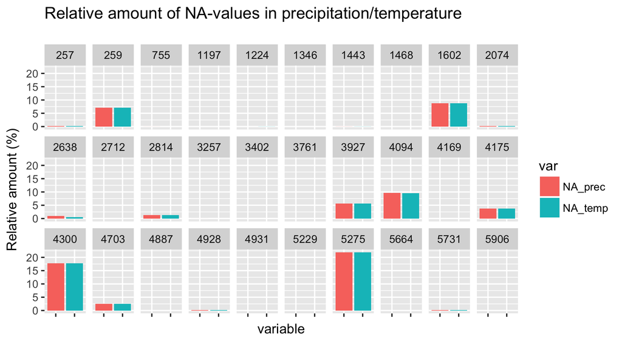

Figure: NA-values (Prec/Temp) in the data set.

# 3 Functions in R

Each climate index should be nested into a R function. Each R function is then loaded on Github to calculate the climate index for other climate stations.

**Discuss in your group:**

- What is the aim of the function? What is a good way to code it?
- What is the input data and in how is this input date formatted?
- Do you have checks for data types and do you stop the function if the data type is wrong?
- What data requirements (e.g. amount of NA) should be considered?
- Have you tested the function with different climate stations/data sets?

Take a break and go to http://r4ds.had.co.nz/functions.html (Book: R for Data Science, Chapter #19 Function):

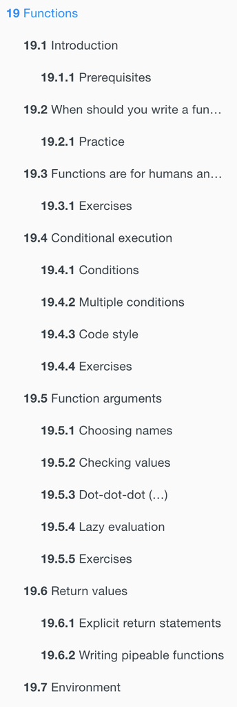

Figure:Overview #19 Functions

## 3.1 Function dummy code (kind of perceptual model)

```r
# ----- Some suggestions for an R function  -----
# ----- Not run, dummy code.  -----

indexABC <- function(x, y, base_period = 1977:1996, detailed.analysis = FALSE) {
  # ----- Breaks -----
  if (!is.Date(x)) stop("x is not Date format.")
  if (!is.numeric(y)) stop("y is not in numeric format.")
  ...
  ...

  # ----- Are packarges required?-----
  require(dplyr)
  require(lubridate)
  ...
  ...

  # ----- Prepare variables for calculation -----
  data <- as.tible(x,y)
  ...
  ...

  # ----- More quality checks... -----
  data %>% filter(years with less then 60 NA-values)
  length(data$years) >= 10
  ...
  ...

  # ----- Detailed analysis part here-----
  if (detailed.analysis) {
    ...
    ...
    ...
  }

  # ----- Return the values-----
  result <- list(m=mean(x), p1=period1, p2=period2, r=ratio)
  return(result)
}

# ----- Test the code-----
test_result <- indexABC(x=climate$date, y=climate$values)
```

# 4 Function repository on github.com

Go to https://github.com/modche/datacourse2018/tree/master/climate_indices

[figure not shown]

Figure:Screenshot github.com